# Projeto Data POA - Receitas

Projeto visando o estudo sobre as receitas do município de Porto Alegre no ano de 2018.  
Dados podem ser encontrados [aqui](http://datapoa.com.br)

## Explorando os dados

```python
# Importação dos pacotes
import pandas as pd
import numpy as np
import seaborn as sns
import matplotlib.pyplot as plt
%matplotlib inline
```

```python
# Carregamento dos dados
df = pd.read_csv('fazenda_receita.csv', encoding='latin-1')
```

```python
#Pequena visão dos dados
df.head()
```

|  | data_extracao | ano | mes | cod_orgao | nome_orgao | cod_categoria | nome_categoria | cod_origem | nome_origem | cod_especie | nome_especie | cod_desdobramento1 | nome_desdobramento1 | cod_tipo | nome_tipo | valor_arrecadado | valor_orcado |
| --- | --- | --- | --- | --- | --- | --- | --- | --- | --- | --- | --- | --- | --- | --- | --- | --- | --- |
| 0 | 2019-09-13 10:14:18 | 2018 | 2 | 1100 | ADMINISTRAÇÃO CENTRALIZADA | 1 | RECEITAS CORRENTES | 11 | IMPOSTOS, TAXAS E CONTRIBUIÇÕES DE MELHORIA | 111 | IMPOSTOS | 1113 | IMPOSTOS SOBRE A RENDA E PROVENTOS DE QUALQUER... | 11130311 | IMPOSTO SOBRE A RENDA - RETIDO NA FONTE - TRAB... | 136631.61 | 0.0 |
| 1 | 2019-09-13 10:14:18 | 2018 | 8 | 1100 | ADMINISTRAÇÃO CENTRALIZADA | 1 | RECEITAS CORRENTES | 11 | IMPOSTOS, TAXAS E CONTRIBUIÇÕES DE MELHORIA | 111 | IMPOSTOS | 1113 | IMPOSTOS SOBRE A RENDA E PROVENTOS DE QUALQUER... | 11130311 | IMPOSTO SOBRE A RENDA - RETIDO NA FONTE - TRAB... | 150241.56 | 0.0 |
| 2 | 2019-09-13 10:14:18 | 2018 | 12 | 1100 | ADMINISTRAÇÃO CENTRALIZADA | 1 | RECEITAS CORRENTES | 11 | IMPOSTOS, TAXAS E CONTRIBUIÇÕES DE MELHORIA | 111 | IMPOSTOS | 1113 | IMPOSTOS SOBRE A RENDA E PROVENTOS DE QUALQUER... | 11130311 | IMPOSTO SOBRE A RENDA - RETIDO NA FONTE - TRAB... | 295878.62 | 0.0 |
| 3 | 2019-09-13 10:14:18 | 2018 | 2 | 1100 | ADMINISTRAÇÃO CENTRALIZADA | 1 | RECEITAS CORRENTES | 11 | IMPOSTOS, TAXAS E CONTRIBUIÇÕES DE MELHORIA | 111 | IMPOSTOS | 1113 | IMPOSTOS SOBRE A RENDA E PROVENTOS DE QUALQUER... | 11130311 | IMPOSTO SOBRE A RENDA - RETIDO NA FONTE - TRAB... | 0.00 | 0.0 |
| 4 | 2019-09-13 10:14:18 | 2018 | 6 | 1100 | ADMINISTRAÇÃO CENTRALIZADA | 1 | RECEITAS CORRENTES | 11 | IMPOSTOS, TAXAS E CONTRIBUIÇÕES DE MELHORIA | 111 | IMPOSTOS | 1113 | IMPOSTOS SOBRE A RENDA E PROVENTOS DE QUALQUER... | 11130311 | IMPOSTO SOBRE A RENDA - RETIDO NA FONTE - TRAB... | 0.00 | 0.0 |

```python
#Informações dos dados
df.info()
```

```
<class 'pandas.core.frame.DataFrame'>
RangeIndex: 12903 entries, 0 to 12902
Data columns (total 17 columns):
data_extracao          12903 non-null object
ano                    12903 non-null int64
mes                    12903 non-null int64
cod_orgao              12903 non-null int64
nome_orgao             12903 non-null object
cod_categoria          12903 non-null int64
nome_categoria         12903 non-null object
cod_origem             12903 non-null int64
nome_origem            12903 non-null object
cod_especie            12903 non-null int64
nome_especie           12843 non-null object
cod_desdobramento1     12903 non-null int64
nome_desdobramento1    6124 non-null object
cod_tipo               12903 non-null int64
nome_tipo              9442 non-null object
valor_arrecadado       12903 non-null float64
valor_orcado           12903 non-null float64
dtypes: float64(2), int64(8), object(7)
memory usage: 1.7+ MB
```

As colunas abaixo não contém o mesmo número de linhas dos demais:

1. nome_especie
2. nome_desdobramento1
3. nome_tipo

```python
print( "Número de nan em nome_especie: ",df.nome_especie.isna().sum())
print( "Número de nan em nome_desdobramento1: ",df.nome_desdobramento1.isna().sum())
print( "Número de nan em nome_tipo: ",df.nome_tipo.isna().sum())
```

```
Número de nan em nome_especie:  60
Número de nan em nome_desdobramento1:  6779
Número de nan em nome_tipo:  3461
```

Notamos que há vários códigos sem as respectivas descrições.  
Isso pode ocorrer devido a falha de cadastro, por exemplo.

Abaixo, salvaremos os códigos para futuras análises.

```python
### Especie ###

# Pegar os códigos sem descrição
list_nan_nome_especie = df[df['nome_especie'].isnull()].cod_especie.tolist()

# Mostrar os códigos distintos
print("Códigos que não tem o 'nome_especie': ", set(list_nan_nome_especie))

# Pegar os índices sem descrição
#df[df['nome_especie'].isnull()].index.tolist()
```

```
Códigos que não tem o 'nome_especie':  {242, 230}
```

```python
### Desdobramento1 ###

# Pegar os códigos sem descrição
list_nan_nome_desdobramento1 = df[df['nome_desdobramento1'].isnull()].cod_desdobramento1.tolist()

# Mostrar os códigos distintos
print("Códigos que não tem o 'nome_desdobramento1': ", set(list_nan_nome_desdobramento1))

# Pegar os índices sem descrição
#df[df['nome_especie'].isnull()].index.tolist()
```

```
Códigos que não tem o 'nome_desdobramento1':  {1921, 1922, 91910, 91922, 1690, 1310, 91690, 7210, 2220, 2990, 2300, 7990, 7610, 1210, 2112, 1990, 1610, 1740, 91990, 1240, 91610, 1121, 1640, 1770, 91121, 7922, 1910, 2428}
```

```python
### Tipo ###

# Pegar os códigos sem descrição
list_nan_nome_tipo = df[df['nome_tipo'].isnull()].cod_tipo.tolist()

# Mostrar os códigos distintos
print("Códigos que não tem o 'nome_tipo': ", set(list_nan_nome_tipo))

# Pegar os índices sem descrição
#df[df['nome_especie'].isnull()].index.tolist()
```

[output not shown]

```python
#Descrição dos dados
df.describe()
```

|  | ano | mes | cod_orgao | cod_categoria | cod_origem | cod_especie | cod_desdobramento1 | cod_tipo | valor_arrecadado | valor_orcado |
| --- | --- | --- | --- | --- | --- | --- | --- | --- | --- | --- |
| count | 12903.0 | 12903.000000 | 12903.000000 | 12903.000000 | 12903.000000 | 12903.000000 | 12903.000000 | 1.290300e+04 | 1.290300e+04 | 1.290300e+04 |
| mean | 2018.0 | 6.568705 | 3182.852360 | 9.837170 | 103.280400 | 1034.952569 | 10351.971247 | 1.035215e+08 | 4.970258e+05 | 3.507923e+06 |
| std | 0.0 | 3.445715 | 2494.066354 | 25.729579 | 257.106654 | 2571.021309 | 25710.722211 | 2.571071e+08 | 3.377837e+06 | 3.408192e+07 |
| min | 2018.0 | 1.000000 | 1100.000000 | 1.000000 | 11.000000 | 111.000000 | 1113.000000 | 1.113031e+07 | -1.936084e+07 | -1.512186e+08 |
| 25% | 2018.0 | 4.000000 | 1100.000000 | 1.000000 | 13.000000 | 132.000000 | 1321.000000 | 1.321001e+07 | 0.000000e+00 | 0.000000e+00 |
| 50% | 2018.0 | 7.000000 | 1211.000000 | 1.000000 | 17.000000 | 172.000000 | 1728.000000 | 1.728012e+07 | 0.000000e+00 | 0.000000e+00 |
| 75% | 2018.0 | 10.000000 | 6100.000000 | 1.000000 | 19.000000 | 199.000000 | 1990.000000 | 1.990991e+07 | 8.730900e+03 | 0.000000e+00 |
| max | 2018.0 | 12.000000 | 7201.000000 | 91.000000 | 919.000000 | 9199.000000 | 91990.000000 | 9.199099e+08 | 1.113059e+08 | 7.138242e+08 |

```python
# Verificação de duplicidade
df_duplicated = df[df.duplicated()]
df_duplicated.shape
```

```
(3305, 17)
```

Na nossa base de dados existem 3305 linhas duplicadas

```python
#nonzero_mean = df[ df.col != 0 ].mean()
#df.loc[ df.col == 0, "col" ] = nonzero_mean

#s = pd.Series([0, 3, 0, 4])
#print(s.to_numpy().nonzero())
#print()
#print(s.iloc[s.to_numpy().nonzero()[0]])

print("Valores duplicados e zerados em Valor Arrecadado e Orçado")
zero_arrecadado = df_duplicated.loc[df.valor_arrecadado == 0]
print("Shape Valor Arrecadado:", zero_arrecadado.shape)
zero_orcado = df_duplicated.loc[df.valor_orcado == 0]
print("Shape Valor Orçado", zero_orcado.shape)
```

```
Valores duplicados e zerados em Valor Arrecadado e Orçado
Shape Valor Arrecadado: (3262, 17)
Shape Valor Orçado (3221, 17)
```

```python
# Backup do Data Frame
df_test = df
```

```python
# Pegar os índices para realizar o drop
zero_arrecadado_index = list(zero_arrecadado.index)
zero_orcado_index = list(zero_orcado.index)
index_to_drop = list(set(zero_arrecadado_index) or set(zero_orcado_index))
```

```python
#list(set(zero_arrecadado_index) & set(zero_orcado_index))
#inter = list(set(zero_arrecadado_index) & set(zero_orcado_index))
#print(len(inter))
#uniao = list(set(zero_arrecadado_index) or set(zero_orcado_index))
#print(len(uniao))
```

```python
#Removendo os valores orçados e arrecadados que são duplicados e zerados
print(df_test.shape)
df_test = df_test.drop(index_to_drop, axis=0)
print(df_test.shape)
```

```
(12903, 17)
(9641, 17)
```

```python
#Verificando se ainda há registros duplicados
df_test_duplicated = df_test[df_test.duplicated()]
df_test_duplicated_index_to_drop = list(df_test_duplicated.index)
df_test = df_test.drop(df_test_duplicated_index_to_drop, axis=0)
```

```python
#Verificando se ainda há duplicidade
df_test.shape
df_test_duplicated = df_test[df_test.duplicated()]
df_test_duplicated.shape
```

```
(0, 17)
```

```python
#Ordenando por mes
df_test.sort_values('mes')
```

|  | data_extracao | ano | mes | cod_orgao | nome_orgao | cod_categoria | nome_categoria | cod_origem | nome_origem | cod_especie | nome_especie | cod_desdobramento1 | nome_desdobramento1 | cod_tipo | nome_tipo | valor_arrecadado | valor_orcado |
| --- | --- | --- | --- | --- | --- | --- | --- | --- | --- | --- | --- | --- | --- | --- | --- | --- | --- |
| 2106 | 2019-09-13 10:14:18 | 2018 | 1 | 1100 | ADMINISTRAÇÃO CENTRALIZADA | 2 | RECEITAS DE CAPITAL | 22 | ALIENAÇÃO DE BENS | 222 | ALIENAÇÃO DE BENS IMÓVEIS | 2220 | NaN | 22200011 | ALIENAÇÃO DE BENS IMÓVEIS - PRINCIPAL | 0.00 | 0.0 |
| 6647 | 2019-09-13 10:14:18 | 2018 | 1 | 1211 | FUNDO PRÓ DEFESA DO MEIO AMBIENTE DE PORTO ALEGRE | 1 | RECEITAS CORRENTES | 13 | RECEITA PATRIMONIAL | 131 | EXPLORAÇÃO DO PATRIMÔNIO IMOBILIÁRIO DO ESTADO | 1310 | NaN | 13100111 | ALUGUÉIS E ARRENDAMENTOS - PRINCIPAL | 38186.02 | 870594.0 |
| 2699 | 2019-09-13 10:14:18 | 2018 | 1 | 1100 | ADMINISTRAÇÃO CENTRALIZADA | 1 | RECEITAS CORRENTES | 13 | RECEITA PATRIMONIAL | 132 | VALORES MOBILIÁRIOS | 1321 | JUROS E CORREÇÕES MONETÁRIAS | 13210011 | REMUNERAÇÃO DE DEPÓSITOS BANCÁRIOS - PRINCIPAL | 4340.80 | 0.0 |
| 2686 | 2019-09-13 10:14:18 | 2018 | 1 | 1100 | ADMINISTRAÇÃO CENTRALIZADA | 1 | RECEITAS CORRENTES | 13 | RECEITA PATRIMONIAL | 131 | EXPLORAÇÃO DO PATRIMÔNIO IMOBILIÁRIO DO ESTADO | 1310 | NaN | 13100211 | CONC. PERM. AUT. CESSÃO DIR. USO BENS IMÓV. PÚ... | 0.00 | 500000.0 |
| 2679 | 2019-09-13 10:14:18 | 2018 | 1 | 1100 | ADMINISTRAÇÃO CENTRALIZADA | 1 | RECEITAS CORRENTES | 11 | IMPOSTOS, TAXAS E CONTRIBUIÇÕES DE MELHORIA | 111 | IMPOSTOS | 1118 | IMPOSTOS ESPECÍFICOS DE ESTADOS, DF E MUNICÍPIOS | 11180234 | IMPOSTO S/ SERV. DE QUALQUER NATUREZA - DÍVIDA... | 86560.75 | 0.0 |
| ... | ... | ... | ... | ... | ... | ... | ... | ... | ... | ... | ... | ... | ... | ... | ... | ... | ... |
| 2888 | 2019-09-13 10:14:18 | 2018 | 12 | 1100 | ADMINISTRAÇÃO CENTRALIZADA | 91 | (-) DEDUÇÕES DAS RECEITAS CORRENTES | 911 | (-) DEDUÇÕES DE IMPOSTOS, TAXAS E CONTRIBUIÇÕE... | 9111 | (-) DEDUÇÕES DE IMPOSTOS | 91118 | (-) DEDUÇÕES DE IMPOSTOS ESPECÍFICOS DE ESTADO... | 911180144 | (-) DEDUÇÕES DE ITBI - DÍVIDA ATIVA - MULTAS E... | 0.00 | 0.0 |
| 6993 | 2019-09-13 10:14:18 | 2018 | 12 | 3100 | DEPARTAMENTO MUNICIPAL DE HABITAÇÃO | 1 | RECEITAS CORRENTES | 13 | RECEITA PATRIMONIAL | 132 | VALORES MOBILIÁRIOS | 1321 | JUROS E CORREÇÕES MONETÁRIAS | 13210011 | REMUNERAÇÃO DE DEPÓSITOS BANCÁRIOS - PRINCIPAL | 2523.09 | 172840.0 |
| 2853 | 2019-09-13 10:14:18 | 2018 | 12 | 1100 | ADMINISTRAÇÃO CENTRALIZADA | 1 | RECEITAS CORRENTES | 13 | RECEITA PATRIMONIAL | 132 | VALORES MOBILIÁRIOS | 1321 | JUROS E CORREÇÕES MONETÁRIAS | 13210011 | REMUNERAÇÃO DE DEPÓSITOS BANCÁRIOS - PRINCIPAL | 1298.58 | 0.0 |
| 7009 | 2019-09-13 10:14:18 | 2018 | 12 | 1215 | FUNDO MUNICIPAL DE REAPARELHAMENTO DO CORPO DE... | 91 | (-) DEDUÇÕES DAS RECEITAS CORRENTES | 911 | (-) DEDUÇÕES DE IMPOSTOS, TAXAS E CONTRIBUIÇÕE... | 9112 | (-) DEDUÇÕES DE TAXAS | 91121 | NaN | 911210111 | NaN | 0.00 | 0.0 |
| 4710 | 2019-09-13 10:14:18 | 2018 | 12 | 1202 | FUNDO MUNICIPAL DE SAÚDE | 2 | RECEITAS DE CAPITAL | 22 | ALIENAÇÃO DE BENS | 221 | ALIENAÇÃO DE BENS MÓVEIS | 2213 | ALIENAÇÃO DE BENS MÓVEIS E SEMOVENTES | 22130011 | ALIENAÇÃO DE BENS MÓVEIS E SEMOVENTES - PRINCIPAL | 0.00 | 0.0 |

9598 rows × 17 columns

```python
#Confirmando que só tem o ano de 2018 e que a data de extração é única
print(set(df_test.data_extracao))
print(set(df_test.ano))
```

```
{'2019-09-13 10:14:18'}
{2018}
```

```python
#Removendo a data_extracao e ano
df_test = df_test.drop(columns = ['data_extracao', 'ano'], axis=1)
```

```python
#Informações do Data Frame
df_test.info()
```

```
<class 'pandas.core.frame.DataFrame'>
Int64Index: 9598 entries, 0 to 12902
Data columns (total 15 columns):
mes                    9598 non-null int64
cod_orgao              9598 non-null int64
nome_orgao             9598 non-null object
cod_categoria          9598 non-null int64
nome_categoria         9598 non-null object
cod_origem             9598 non-null int64
nome_origem            9598 non-null object
cod_especie            9598 non-null int64
nome_especie           9538 non-null object
cod_desdobramento1     9598 non-null int64
nome_desdobramento1    4400 non-null object
cod_tipo               9598 non-null int64
nome_tipo              7217 non-null object
valor_arrecadado       9598 non-null float64
valor_orcado           9598 non-null float64
dtypes: float64(2), int64(7), object(6)
memory usage: 1.2+ MB
```

Temos que apenas as colunas 'nome_especie', 'nome_desdobramento1' e 'nome_tipo' ainda apresentam valores faltantes.  
Vamos substituir por "NÃO INFORMADO".

```python
#Substituindo os nan values por 'NÃO INFORMADO'
df_test['nome_especie'].fillna("NÃO INFORMADO", inplace=True)
df_test['nome_desdobramento1'].fillna("NÃO INFORMADO", inplace=True)
df_test['nome_tipo'].fillna("NÃO INFORMADO", inplace=True)
```

```python
#Verificando que não há nan values
df_test.info()
```

```
<class 'pandas.core.frame.DataFrame'>
Int64Index: 9598 entries, 0 to 12902
Data columns (total 15 columns):
mes                    9598 non-null int64
cod_orgao              9598 non-null int64
nome_orgao             9598 non-null object
cod_categoria          9598 non-null int64
nome_categoria         9598 non-null object
cod_origem             9598 non-null int64
nome_origem            9598 non-null object
cod_especie            9598 non-null int64
nome_especie           9598 non-null object
cod_desdobramento1     9598 non-null int64
nome_desdobramento1    9598 non-null object
cod_tipo               9598 non-null int64
nome_tipo              9598 non-null object
valor_arrecadado       9598 non-null float64
valor_orcado           9598 non-null float64
dtypes: float64(2), int64(7), object(6)
memory usage: 1.2+ MB
```

## Análise Top 5 - Mensal

### Janeiro

```python
#Salvando apenas os dados do mês de Janeiro
df_jan = df_test.loc[df_test.mes == 1]
```

```python
#Agrupamento dos valores orçados e arrecadados

df_jan = df_jan.groupby(['nome_orgao'])['valor_orcado', 'valor_arrecadado'].sum()
#print(df_jan['valor_orcado'].sort_values(ascending=False))
jan_orcado = df_jan['valor_orcado'].sort_values()
```

```python
print(type(df_jan.valor_orcado))
print(type(df_jan.index))
```

```
<class 'pandas.core.series.Series'>
<class 'pandas.core.indexes.base.Index'>
```

```python
#Gráfico Valor Orçado

jan_orcado = jan_orcado.sort_values(ascending=False)[0:5]
jan_orcado.sort_values().plot(figsize=(10,3), kind='barh', title="Top 5 - Valores orçados por órgão")
plt.show()
```

[output not shown]

```python
#print(df_janeiro['valor_arrecadado'].sort_values(ascending=False))
jan_arrecadado = df_jan['valor_arrecadado'].sort_values()
```

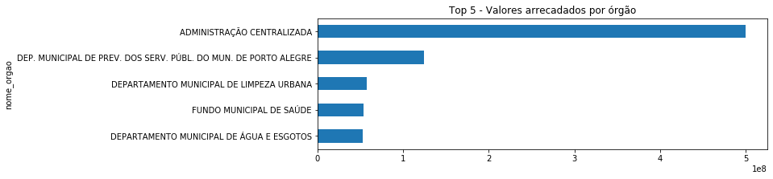

```python
#Gráfico Valor Arrecadado

jan_arrecadado = jan_arrecadado.sort_values(ascending=False)[0:5]
jan_arrecadado.sort_values().plot(figsize=(10,3), kind='barh', title="Top 5 - Valores arrecadados por órgão")
plt.show()
```

Observações:  
1.Os órgãos são os mesmos em ambos os gráficos, porém apenas a Administração Centralizada está na mesma posição em ambos (1º)  
2.Todos os órgãos obtiveram déficit, como é mostrado abaixo:

```python
#Cálculo do déficit (ou superávit) e formatação para Real

def_saude_jan = (df_jan['valor_arrecadado']['FUNDO MUNICIPAL DE SAÚDE'] - df_jan['valor_orcado']['FUNDO MUNICIPAL DE SAÚDE'])

def_prev_jan = (df_jan['valor_arrecadado']['DEP. MUNICIPAL DE PREV. DOS SERV. PÚBL. DO MUN. DE PORTO ALEGRE'] -
                df_jan['valor_orcado']['DEP. MUNICIPAL DE PREV. DOS SERV. PÚBL. DO MUN. DE PORTO ALEGRE'])

def_adm_jan = (df_jan['valor_arrecadado']['ADMINISTRAÇÃO CENTRALIZADA'] -
               df_jan['valor_orcado']['ADMINISTRAÇÃO CENTRALIZADA'])

def_agua_jan = (df_jan['valor_arrecadado']['DEPARTAMENTO MUNICIPAL DE ÁGUA E ESGOTOS'] -
                df_jan['valor_orcado']['DEPARTAMENTO MUNICIPAL DE ÁGUA E ESGOTOS'])

def_limpeza_jan = (df_jan['valor_arrecadado']['DEPARTAMENTO MUNICIPAL DE LIMPEZA URBANA'] -
                   df_jan['valor_orcado']['DEPARTAMENTO MUNICIPAL DE LIMPEZA URBANA'])

def_saude_jan_format = 'R${:,.2f}'.format(def_saude_jan)
def_prev_jan_format = 'R${:,.2f}'.format(def_prev_jan)
def_adm_jan_format = 'R${:,.2f}'.format(def_adm_jan)
def_agua_jan_format = 'R${:,.2f}'.format(def_agua_jan)
def_limpeza_jan_format = 'R${:,.2f}'.format(def_limpeza_jan)
```

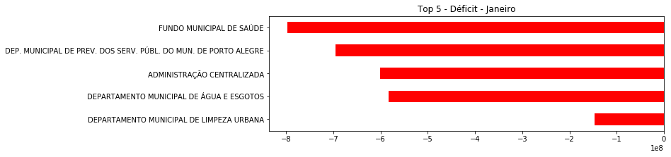

```python
#Gráfico Déficit

x_jan = ["FUNDO MUNICIPAL DE SAÚDE", "DEP. MUNICIPAL DE PREV. DOS SERV. PÚBL. DO MUN. DE PORTO ALEGRE",
         "ADMINISTRAÇÃO CENTRALIZADA", "DEPARTAMENTO MUNICIPAL DE ÁGUA E ESGOTOS", "DEPARTAMENTO MUNICIPAL DE LIMPEZA URBANA"]
y_jan = [def_saude_jan, def_prev_jan, def_adm_jan, def_agua_jan, def_limpeza_jan]

ser_jan = pd.Series(y_jan, index=x_jan)
#print(ser_jan)

ser_jan.sort_values(ascending=False).plot(figsize=(10,3), kind='barh', title="Top 5 - Déficit - Janeiro", color="red")
plt.show()
```

```python
#Déficit Formatado

print("Fundo Municipal de Saúde:                                       ", def_saude_jan_format)
print("Dep. Municipal de Prev. dos Serv. Públ. do Mun. de Porto Alegre:", def_prev_jan_format)
print("Administração Centralizada:                                     ", def_adm_jan_format)
print("Departamento Municipal de Água e Esgotos:                       ", def_agua_jan_format)
print("Departamento Municipal de Limpeza Urbana:                       ", def_limpeza_jan_format)
```

```
Fundo Municipal de Saúde:                                        R$-796,861,889.65
Dep. Municipal de Prev. dos Serv. Públ. do Mun. de Porto Alegre: R$-695,951,782.50
Administração Centralizada:                                      R$-600,457,041.77
Departamento Municipal de Água e Esgotos:                        R$-583,816,683.53
Departamento Municipal de Limpeza Urbana:                        R$-146,157,137.99
```

### Fevereiro

```python
#Salvando apenas os dados do mês de Fevereiro
df_fev = df_test.loc[df_test.mes == 2]
```

```python
#Agrupamento dos valores orçados e arrecadados

df_fev = df_fev.groupby(['nome_orgao'])['valor_orcado', 'valor_arrecadado'].sum()
#print(df_fev['valor_orcado'].sort_values(ascending=False))
fev_orcado = df_fev['valor_orcado'].sort_values()
```

```python
#Gráfico Valor Orçado

fev_orcado = fev_orcado.sort_values(ascending=False)[0:5]
fev_orcado.sort_values().plot(figsize=(10,3), kind='barh', title="Top 5 - Valores orçados por órgão")
plt.show()
```

[output not shown]

```python
#print(df_fev['valor_arrecadado'].sort_values(ascending=False))
fev_arrecadado = df_fev['valor_arrecadado'].sort_values()
```

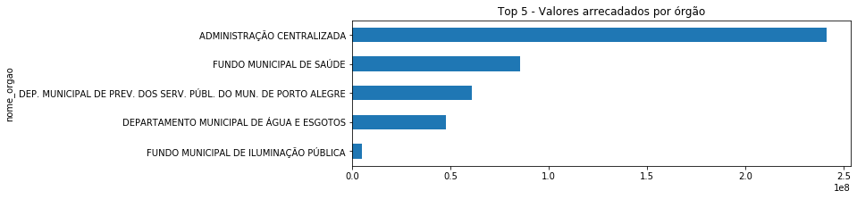

```python
#Gráfico Valor Arrecadado

fev_arrecadado = fev_arrecadado.sort_values(ascending=False)[0:5]
fev_arrecadado.sort_values().plot(figsize=(10,3), kind='barh', title="Top 5 - Valores arrecadados por órgão")
plt.show()
```

```python
#Cálculo do déficit (ou superávit) e formatação para Real

def_saude_fev = (df_fev['valor_arrecadado']['FUNDO MUNICIPAL DE SAÚDE'] - df_fev['valor_orcado']['FUNDO MUNICIPAL DE SAÚDE'])

def_prev_fev = (df_fev['valor_arrecadado']['DEP. MUNICIPAL DE PREV. DOS SERV. PÚBL. DO MUN. DE PORTO ALEGRE'] -
                df_fev['valor_orcado']['DEP. MUNICIPAL DE PREV. DOS SERV. PÚBL. DO MUN. DE PORTO ALEGRE'])

def_adm_fev = (df_fev['valor_arrecadado']['ADMINISTRAÇÃO CENTRALIZADA'] -
               df_fev['valor_orcado']['ADMINISTRAÇÃO CENTRALIZADA'])

def_agua_fev = (df_fev['valor_arrecadado']['DEPARTAMENTO MUNICIPAL DE ÁGUA E ESGOTOS'] -
                df_fev['valor_orcado']['DEPARTAMENTO MUNICIPAL DE ÁGUA E ESGOTOS'])

def_limpeza_fev = (df_fev['valor_arrecadado']['DEPARTAMENTO MUNICIPAL DE LIMPEZA URBANA'] -
                   df_fev['valor_orcado']['DEPARTAMENTO MUNICIPAL DE LIMPEZA URBANA'])

def_saude_fev_format = 'R${:,.2f}'.format(def_saude_fev)
def_prev_fev_format = 'R${:,.2f}'.format(def_prev_fev)
def_adm_fev_format = 'R${:,.2f}'.format(def_adm_fev)
def_agua_fev_format = 'R${:,.2f}'.format(def_agua_fev)
def_limpeza_fev_format = 'R${:,.2f}'.format(def_limpeza_fev)
```

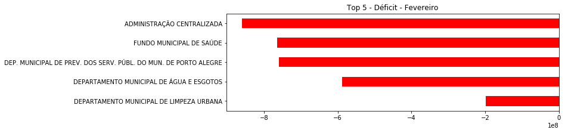

```python
#Gráfico Déficit

x_fev = ["FUNDO MUNICIPAL DE SAÚDE", "DEP. MUNICIPAL DE PREV. DOS SERV. PÚBL. DO MUN. DE PORTO ALEGRE",
         "ADMINISTRAÇÃO CENTRALIZADA", "DEPARTAMENTO MUNICIPAL DE ÁGUA E ESGOTOS", "DEPARTAMENTO MUNICIPAL DE LIMPEZA URBANA"]
y_fev = [def_saude_fev, def_prev_fev, def_adm_fev, def_agua_fev, def_limpeza_fev]

ser_fev = pd.Series(y_fev, index=x_fev)
#print(ser_fev.sort_values())

ser_fev.sort_values(ascending=False).plot(figsize=(10,3), kind='barh', title="Top 5 - Déficit - Fevereiro", color="red")
plt.show()
```

```python
#Déficit Formatado

print("Administração Centralizada:                                     ", def_adm_fev_format)
print("Fundo Municipal de Saúde:                                       ", def_saude_fev_format)
print("Dep. Municipal de Prev. dos Serv. Públ. do Mun. de Porto Alegre:", def_prev_fev_format)
print("Departamento Municipal de Água e Esgotos:                       ", def_agua_fev_format)
print("Departamento Municipal de Limpeza Urbana:                       ", def_limpeza_fev_format)
```

```
Administração Centralizada:                                      R$-859,009,087.33
Fundo Municipal de Saúde:                                        R$-765,086,199.29
Dep. Municipal de Prev. dos Serv. Públ. do Mun. de Porto Alegre: R$-759,899,650.29
Departamento Municipal de Água e Esgotos:                        R$-588,547,056.59
Departamento Municipal de Limpeza Urbana:                        R$-199,415,807.06
```

```python
#'R${:,.2f}'.format(def_saude_fev)
```

### Março

```python
#Salvando apenas os dados do mês de Março
df_mar = df_test.loc[df_test.mes == 3]
```

```python
#Agrupamento dos valores orçados e arrecadados

df_mar = df_mar.groupby(['nome_orgao'])['valor_orcado', 'valor_arrecadado'].sum()
#print(df_mar['valor_orcado'].sort_values(ascending=False))
mar_orcado = df_mar['valor_orcado'].sort_values()
```

```python
#Gráfico Valor Orçado

mar_orcado = mar_orcado.sort_values(ascending=False)[0:5]
mar_orcado.sort_values().plot(figsize=(10,3), kind='barh', title="Top 5 - Valores orçados por órgão")
plt.show()
```

[output not shown]

```python
#print(df_mar['valor_arrecadado'].sort_values(ascending=False))
mar_arrecadado = df_mar['valor_arrecadado'].sort_values()
```

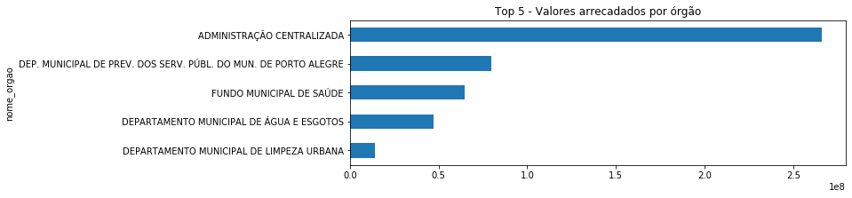

```python
#Gráfico Valor Arrecadado

mar_arrecadado = mar_arrecadado.sort_values(ascending=False)[0:5]
mar_arrecadado.sort_values().plot(figsize=(10,3), kind='barh', title="Top 5 - Valores arrecadados por órgão")
plt.show()
```

```python
#Cálculo do déficit (ou superávit) e formatação para Real

def_saude_mar = (df_mar['valor_arrecadado']['FUNDO MUNICIPAL DE SAÚDE'] - df_mar['valor_orcado']['FUNDO MUNICIPAL DE SAÚDE'])

def_prev_mar = (df_mar['valor_arrecadado']['DEP. MUNICIPAL DE PREV. DOS SERV. PÚBL. DO MUN. DE PORTO ALEGRE'] -
                df_mar['valor_orcado']['DEP. MUNICIPAL DE PREV. DOS SERV. PÚBL. DO MUN. DE PORTO ALEGRE'])

def_adm_mar = (df_mar['valor_arrecadado']['ADMINISTRAÇÃO CENTRALIZADA'] -
               df_mar['valor_orcado']['ADMINISTRAÇÃO CENTRALIZADA'])

def_agua_mar = (df_mar['valor_arrecadado']['DEPARTAMENTO MUNICIPAL DE ÁGUA E ESGOTOS'] -
                df_mar['valor_orcado']['DEPARTAMENTO MUNICIPAL DE ÁGUA E ESGOTOS'])

def_limpeza_mar = (df_mar['valor_arrecadado']['DEPARTAMENTO MUNICIPAL DE LIMPEZA URBANA'] -
                   df_mar['valor_orcado']['DEPARTAMENTO MUNICIPAL DE LIMPEZA URBANA'])

def_saude_mar_format = 'R${:,.2f}'.format(def_saude_mar)
def_prev_mar_format = 'R${:,.2f}'.format(def_prev_mar)
def_adm_mar_format = 'R${:,.2f}'.format(def_adm_mar)
def_agua_mar_format = 'R${:,.2f}'.format(def_agua_mar)
def_limpeza_mar_format = 'R${:,.2f}'.format(def_limpeza_mar)
```

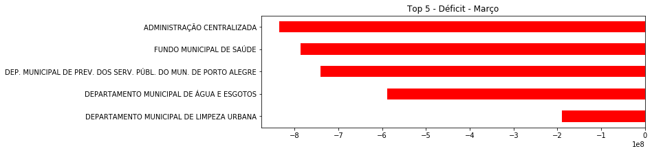

```python
#Gráfico Déficit

x_mar = ["FUNDO MUNICIPAL DE SAÚDE", "DEP. MUNICIPAL DE PREV. DOS SERV. PÚBL. DO MUN. DE PORTO ALEGRE",
         "ADMINISTRAÇÃO CENTRALIZADA", "DEPARTAMENTO MUNICIPAL DE ÁGUA E ESGOTOS", "DEPARTAMENTO MUNICIPAL DE LIMPEZA URBANA"]
y_mar = [def_saude_mar, def_prev_mar, def_adm_mar, def_agua_mar, def_limpeza_mar]

ser_mar = pd.Series(y_mar, index=x_mar)
#print(ser_mar.sort_values())

ser_mar.sort_values(ascending=False).plot(figsize=(10,3), kind='barh', title="Top 5 - Déficit - Março", color="red")
plt.show()
```

```python
#Déficit Formatado

print("Administração Centralizada:                                     ", def_adm_mar_format)
print("Fundo Municipal de Saúde:                                       ", def_saude_mar_format)
print("Dep. Municipal de Prev. dos Serv. Públ. do Mun. de Porto Alegre:", def_prev_mar_format)
print("Departamento Municipal de Água e Esgotos:                       ", def_agua_mar_format)
print("Departamento Municipal de Limpeza Urbana:                       ", def_limpeza_mar_format)
```

```
Administração Centralizada:                                      R$-834,180,242.53
Fundo Municipal de Saúde:                                        R$-785,790,349.27
Dep. Municipal de Prev. dos Serv. Públ. do Mun. de Porto Alegre: R$-741,099,635.43
Departamento Municipal de Água e Esgotos:                        R$-588,972,954.03
Departamento Municipal de Limpeza Urbana:                        R$-189,542,286.23
```

### Abril

```python
#Salvando apenas os dados do mês de Abril
df_abr = df_test.loc[df_test.mes == 4]
```

```python
#Agrupamento dos valores orçados e arrecadados

df_abr = df_abr.groupby(['nome_orgao'])['valor_orcado', 'valor_arrecadado'].sum()
#print(df_abr['valor_orcado'].sort_values(ascending=False))
abr_orcado = df_abr['valor_orcado'].sort_values()
```

```python
#Gráfico Valor Orçado

abr_orcado = abr_orcado.sort_values(ascending=False)[0:5]
abr_orcado.sort_values().plot(figsize=(10,3), kind='barh', title="Top 5 - Valores orçados por órgão")
plt.show()
```

[output not shown]

```python
#print(df_abr['valor_arrecadado'].sort_values(ascending=False))
abr_arrecadado = df_abr['valor_arrecadado'].sort_values()
```

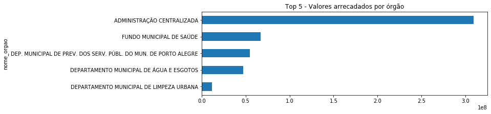

```python
#Gráfico Valor Arrecadado

abr_arrecadado = abr_arrecadado.sort_values(ascending=False)[0:5]
abr_arrecadado.sort_values().plot(figsize=(10,3), kind='barh', title="Top 5 - Valores arrecadados por órgão")
plt.show()
```

```python
#Cálculo do déficit (ou superávit) e formatação para Real

def_saude_abr = (df_abr['valor_arrecadado']['FUNDO MUNICIPAL DE SAÚDE'] - df_abr['valor_orcado']['FUNDO MUNICIPAL DE SAÚDE'])

def_prev_abr = (df_abr['valor_arrecadado']['DEP. MUNICIPAL DE PREV. DOS SERV. PÚBL. DO MUN. DE PORTO ALEGRE'] -
                df_abr['valor_orcado']['DEP. MUNICIPAL DE PREV. DOS SERV. PÚBL. DO MUN. DE PORTO ALEGRE'])

def_adm_abr = (df_abr['valor_arrecadado']['ADMINISTRAÇÃO CENTRALIZADA'] -
               df_abr['valor_orcado']['ADMINISTRAÇÃO CENTRALIZADA'])

def_agua_abr = (df_abr['valor_arrecadado']['DEPARTAMENTO MUNICIPAL DE ÁGUA E ESGOTOS'] -
                df_abr['valor_orcado']['DEPARTAMENTO MUNICIPAL DE ÁGUA E ESGOTOS'])

def_limpeza_abr = (df_abr['valor_arrecadado']['DEPARTAMENTO MUNICIPAL DE LIMPEZA URBANA'] -
                   df_abr['valor_orcado']['DEPARTAMENTO MUNICIPAL DE LIMPEZA URBANA'])

def_saude_abr_format = 'R${:,.2f}'.format(def_saude_abr)
def_prev_abr_format = 'R${:,.2f}'.format(def_prev_abr)
def_adm_abr_format = 'R${:,.2f}'.format(def_adm_abr)
def_agua_abr_format = 'R${:,.2f}'.format(def_agua_abr)
def_limpeza_abr_format = 'R${:,.2f}'.format(def_limpeza_abr)
```

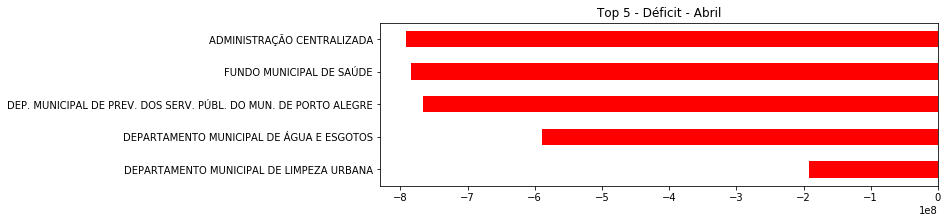

```python
#Gráfico Déficit

x_abr = ["FUNDO MUNICIPAL DE SAÚDE", "DEP. MUNICIPAL DE PREV. DOS SERV. PÚBL. DO MUN. DE PORTO ALEGRE",
         "ADMINISTRAÇÃO CENTRALIZADA", "DEPARTAMENTO MUNICIPAL DE ÁGUA E ESGOTOS", "DEPARTAMENTO MUNICIPAL DE LIMPEZA URBANA"]
y_abr = [def_saude_abr, def_prev_abr, def_adm_abr, def_agua_abr, def_limpeza_abr]

ser_abr = pd.Series(y_abr, index=x_abr)
#print(ser_abr.sort_values())

ser_abr.sort_values(ascending=False).plot(figsize=(10,3), kind='barh', title="Top 5 - Déficit - Abril", color="red")
plt.show()
```

```python
#Déficit Formatado

print("Administração Centralizada:                                     ", def_adm_abr_format)
print("Fundo Municipal de Saúde:                                       ", def_saude_abr_format)
print("Dep. Municipal de Prev. dos Serv. Públ. do Mun. de Porto Alegre:", def_prev_abr_format)
print("Departamento Municipal de Água e Esgotos:                       ", def_agua_abr_format)
print("Departamento Municipal de Limpeza Urbana:                       ", def_limpeza_abr_format)
```

```
Administração Centralizada:                                      R$-790,909,764.90
Fundo Municipal de Saúde:                                        R$-783,496,647.08
Dep. Municipal de Prev. dos Serv. Públ. do Mun. de Porto Alegre: R$-765,669,542.08
Departamento Municipal de Água e Esgotos:                        R$-588,917,813.30
Departamento Municipal de Limpeza Urbana:                        R$-191,806,945.44
```

### Maio

```python
#Salvando apenas os dados do mês de Maio
df_mai = df_test.loc[df_test.mes == 5]
```

```python
#Agrupamento dos valores orçados e arrecadados

df_mai = df_mai.groupby(['nome_orgao'])['valor_orcado', 'valor_arrecadado'].sum()
#print(df_mai['valor_orcado'].sort_values(ascending=False))
mai_orcado = df_mai['valor_orcado'].sort_values()
```

```python
#Gráfico Valor Orçado

mai_orcado = mai_orcado.sort_values(ascending=False)[0:5]
mai_orcado.sort_values().plot(figsize=(10,3), kind='barh', title="Top 5 - Valores orçados por órgão")
plt.show()
```

[output not shown]

```python
#print(df_mai['valor_arrecadado'].sort_values(ascending=False))
mai_arrecadado = df_mai['valor_arrecadado'].sort_values()
```

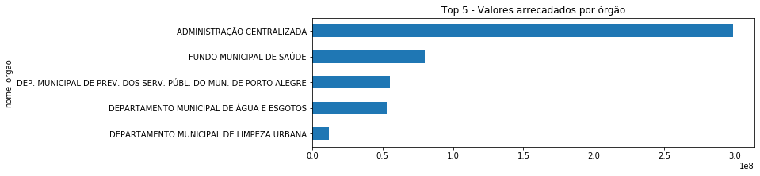

```python
#Gráfico Valor Arrecadado

mai_arrecadado = mai_arrecadado.sort_values(ascending=False)[0:5]
mai_arrecadado.sort_values().plot(figsize=(10,3), kind='barh', title="Top 5 - Valores arrecadados por órgão")
plt.show()
```

```python
#Cálculo do déficit (ou superávit) e formatação para Real

def_saude_mai = (df_mai['valor_arrecadado']['FUNDO MUNICIPAL DE SAÚDE'] - df_mai['valor_orcado']['FUNDO MUNICIPAL DE SAÚDE'])

def_prev_mai = (df_mai['valor_arrecadado']['DEP. MUNICIPAL DE PREV. DOS SERV. PÚBL. DO MUN. DE PORTO ALEGRE'] -
                df_mai['valor_orcado']['DEP. MUNICIPAL DE PREV. DOS SERV. PÚBL. DO MUN. DE PORTO ALEGRE'])

def_adm_mai = (df_mai['valor_arrecadado']['ADMINISTRAÇÃO CENTRALIZADA'] -
               df_mai['valor_orcado']['ADMINISTRAÇÃO CENTRALIZADA'])

def_agua_mai = (df_mai['valor_arrecadado']['DEPARTAMENTO MUNICIPAL DE ÁGUA E ESGOTOS'] -
                df_mai['valor_orcado']['DEPARTAMENTO MUNICIPAL DE ÁGUA E ESGOTOS'])

def_limpeza_mai = (df_mai['valor_arrecadado']['DEPARTAMENTO MUNICIPAL DE LIMPEZA URBANA'] -
                   df_mai['valor_orcado']['DEPARTAMENTO MUNICIPAL DE LIMPEZA URBANA'])

def_saude_mai_format = 'R${:,.2f}'.format(def_saude_mai)
def_prev_mai_format = 'R${:,.2f}'.format(def_prev_mai)
def_adm_mai_format = 'R${:,.2f}'.format(def_adm_mai)
def_agua_mai_format = 'R${:,.2f}'.format(def_agua_mai)
def_limpeza_mai_format = 'R${:,.2f}'.format(def_limpeza_mai)
```

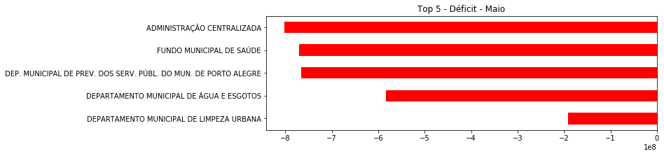

```python
#Gráfico Déficit

x_mai = ["FUNDO MUNICIPAL DE SAÚDE", "DEP. MUNICIPAL DE PREV. DOS SERV. PÚBL. DO MUN. DE PORTO ALEGRE",
         "ADMINISTRAÇÃO CENTRALIZADA", "DEPARTAMENTO MUNICIPAL DE ÁGUA E ESGOTOS", "DEPARTAMENTO MUNICIPAL DE LIMPEZA URBANA"]
y_mai = [def_saude_mai, def_prev_mai, def_adm_mai, def_agua_mai, def_limpeza_mai]

ser_mai = pd.Series(y_mai, index=x_mai)
#print(ser_mai.sort_values())

ser_mai.sort_values(ascending=False).plot(figsize=(10,3), kind='barh', title="Top 5 - Déficit - Maio", color="red")
plt.show()
```

```python
#Déficit Formatado

print("Administração Centralizada:                                     ", def_adm_mai_format)
print("Fundo Municipal de Saúde:                                       ", def_saude_mai_format)
print("Dep. Municipal de Prev. dos Serv. Públ. do Mun. de Porto Alegre:", def_prev_mai_format)
print("Departamento Municipal de Água e Esgotos:                       ", def_agua_mai_format)
print("Departamento Municipal de Limpeza Urbana:                       ", def_limpeza_mai_format)
```

```
Administração Centralizada:                                      R$-801,422,244.41
Fundo Municipal de Saúde:                                        R$-770,689,469.68
Dep. Municipal de Prev. dos Serv. Públ. do Mun. de Porto Alegre: R$-765,539,264.61
Departamento Municipal de Água e Esgotos:                        R$-583,645,852.14
Departamento Municipal de Limpeza Urbana:                        R$-192,065,022.15
```

### Junho

```python
#Salvando apenas os dados do mês de Junho
df_jun = df_test.loc[df_test.mes == 6]
```

```python
#Agrupamento dos valores orçados e arrecadados

df_jun = df_jun.groupby(['nome_orgao'])['valor_orcado', 'valor_arrecadado'].sum()
#print(df_jun['valor_orcado'].sort_values(ascending=False))
jun_orcado = df_jun['valor_orcado'].sort_values()
```

```python
#Gráfico Valor Orçado

jun_orcado = jun_orcado.sort_values(ascending=False)[0:5]
jun_orcado.sort_values().plot(figsize=(10,3), kind='barh', title="Top 5 - Valores orçados por órgão")
plt.show()
```

[output not shown]

```python
#print(df_jun['valor_arrecadado'].sort_values(ascending=False))
jun_arrecadado = df_jun['valor_arrecadado'].sort_values()
```

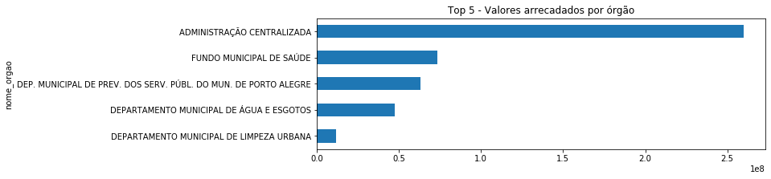

```python
#Gráfico Valor Arrecadado

jun_arrecadado = jun_arrecadado.sort_values(ascending=False)[0:5]
jun_arrecadado.sort_values().plot(figsize=(10,3), kind='barh', title="Top 5 - Valores arrecadados por órgão")
plt.show()
```

```python
#Cálculo do déficit (ou superávit) e formatação para Real

def_saude_jun = (df_jun['valor_arrecadado']['FUNDO MUNICIPAL DE SAÚDE'] - df_jun['valor_orcado']['FUNDO MUNICIPAL DE SAÚDE'])

def_prev_jun = (df_jun['valor_arrecadado']['DEP. MUNICIPAL DE PREV. DOS SERV. PÚBL. DO MUN. DE PORTO ALEGRE'] -
                df_jun['valor_orcado']['DEP. MUNICIPAL DE PREV. DOS SERV. PÚBL. DO MUN. DE PORTO ALEGRE'])

def_adm_jun = (df_jun['valor_arrecadado']['ADMINISTRAÇÃO CENTRALIZADA'] -
               df_jun['valor_orcado']['ADMINISTRAÇÃO CENTRALIZADA'])

def_agua_jun = (df_jun['valor_arrecadado']['DEPARTAMENTO MUNICIPAL DE ÁGUA E ESGOTOS'] -
                df_jun['valor_orcado']['DEPARTAMENTO MUNICIPAL DE ÁGUA E ESGOTOS'])

def_limpeza_jun = (df_jun['valor_arrecadado']['DEPARTAMENTO MUNICIPAL DE LIMPEZA URBANA'] -
                   df_jun['valor_orcado']['DEPARTAMENTO MUNICIPAL DE LIMPEZA URBANA'])

def_saude_jun_format = 'R${:,.2f}'.format(def_saude_jun)
def_prev_jun_format = 'R${:,.2f}'.format(def_prev_jun)
def_adm_jun_format = 'R${:,.2f}'.format(def_adm_jun)
def_agua_jun_format = 'R${:,.2f}'.format(def_agua_jun)
def_limpeza_jun_format = 'R${:,.2f}'.format(def_limpeza_jun)
```

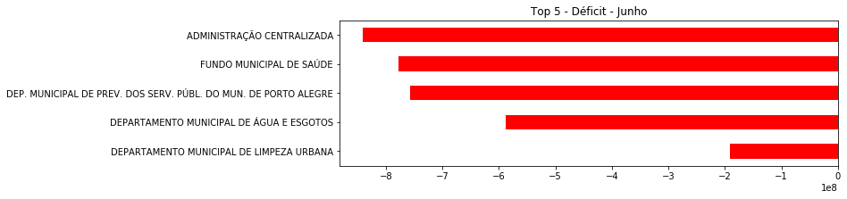

```python
#Gráfico Déficit

x_jun = ["FUNDO MUNICIPAL DE SAÚDE", "DEP. MUNICIPAL DE PREV. DOS SERV. PÚBL. DO MUN. DE PORTO ALEGRE",
         "ADMINISTRAÇÃO CENTRALIZADA", "DEPARTAMENTO MUNICIPAL DE ÁGUA E ESGOTOS", "DEPARTAMENTO MUNICIPAL DE LIMPEZA URBANA"]
y_jun = [def_saude_jun, def_prev_jun, def_adm_jun, def_agua_jun, def_limpeza_jun]

ser_jun = pd.Series(y_jun, index=x_jun)
#print(ser_jun.sort_values())

ser_jun.sort_values(ascending=False).plot(figsize=(10,3), kind='barh', title="Top 5 - Déficit - Junho", color="red")
plt.show()
```

```python
#Déficit Formatado

print("Administração Centralizada:                                     ", def_adm_jun_format)
print("Fundo Municipal de Saúde:                                       ", def_saude_jun_format)
print("Dep. Municipal de Prev. dos Serv. Públ. do Mun. de Porto Alegre:", def_prev_jun_format)
print("Departamento Municipal de Água e Esgotos:                       ", def_agua_jun_format)
print("Departamento Municipal de Limpeza Urbana:                       ", def_limpeza_jun_format)
```

```
Administração Centralizada:                                      R$-840,382,475.79
Fundo Municipal de Saúde:                                        R$-777,415,434.75
Dep. Municipal de Prev. dos Serv. Públ. do Mun. de Porto Alegre: R$-757,637,678.64
Departamento Municipal de Água e Esgotos:                        R$-588,706,090.33
Departamento Municipal de Limpeza Urbana:                        R$-191,852,936.44
```

### Julho

```python
#Salvando apenas os dados do mês de Julho
df_jul = df_test.loc[df_test.mes == 7]
```

```python
#Agrupamento dos valores orçados e arrecadados

df_jul = df_jul.groupby(['nome_orgao'])['valor_orcado', 'valor_arrecadado'].sum()
#print(df_jul['valor_orcado'].sort_values(ascending=False))
jul_orcado = df_jul['valor_orcado'].sort_values()
```

```python
#Gráfico Valor Orçado

jul_orcado = jul_orcado.sort_values(ascending=False)[0:5]
jul_orcado.sort_values().plot(figsize=(10,3), kind='barh', title="Top 5 - Valores orçados por órgão")
plt.show()
```

[output not shown]

```python
#print(df_jul['valor_arrecadado'].sort_values(ascending=False))
jul_arrecadado = df_jul['valor_arrecadado'].sort_values()
```

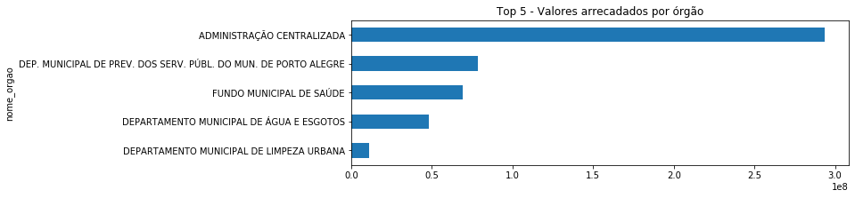

```python
#Gráfico Valor Arrecadado

jul_arrecadado = jul_arrecadado.sort_values(ascending=False)[0:5]
jul_arrecadado.sort_values().plot(figsize=(10,3), kind='barh', title="Top 5 - Valores arrecadados por órgão")
plt.show()
```

```python
#Cálculo do déficit (ou superávit) e formatação para Real

def_saude_jul = (df_jul['valor_arrecadado']['FUNDO MUNICIPAL DE SAÚDE'] - df_jul['valor_orcado']['FUNDO MUNICIPAL DE SAÚDE'])

def_prev_jul = (df_jul['valor_arrecadado']['DEP. MUNICIPAL DE PREV. DOS SERV. PÚBL. DO MUN. DE PORTO ALEGRE'] -
                df_jul['valor_orcado']['DEP. MUNICIPAL DE PREV. DOS SERV. PÚBL. DO MUN. DE PORTO ALEGRE'])

def_adm_jul = (df_jul['valor_arrecadado']['ADMINISTRAÇÃO CENTRALIZADA'] -
               df_jul['valor_orcado']['ADMINISTRAÇÃO CENTRALIZADA'])

def_agua_jul = (df_jul['valor_arrecadado']['DEPARTAMENTO MUNICIPAL DE ÁGUA E ESGOTOS'] -
                df_jul['valor_orcado']['DEPARTAMENTO MUNICIPAL DE ÁGUA E ESGOTOS'])

def_limpeza_jul = (df_jul['valor_arrecadado']['DEPARTAMENTO MUNICIPAL DE LIMPEZA URBANA'] -
                   df_jul['valor_orcado']['DEPARTAMENTO MUNICIPAL DE LIMPEZA URBANA'])

def_saude_jul_format = 'R${:,.2f}'.format(def_saude_jul)
def_prev_jul_format = 'R${:,.2f}'.format(def_prev_jul)
def_adm_jul_format = 'R${:,.2f}'.format(def_adm_jul)
def_agua_jul_format = 'R${:,.2f}'.format(def_agua_jul)
def_limpeza_jul_format = 'R${:,.2f}'.format(def_limpeza_jul)
```

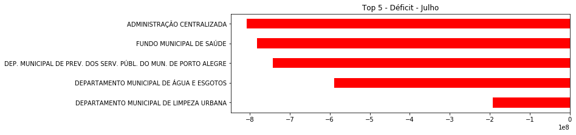

```python
#Gráfico Déficit

x_jul = ["FUNDO MUNICIPAL DE SAÚDE", "DEP. MUNICIPAL DE PREV. DOS SERV. PÚBL. DO MUN. DE PORTO ALEGRE",
         "ADMINISTRAÇÃO CENTRALIZADA", "DEPARTAMENTO MUNICIPAL DE ÁGUA E ESGOTOS", "DEPARTAMENTO MUNICIPAL DE LIMPEZA URBANA"]
y_jul = [def_saude_jul, def_prev_jul, def_adm_jul, def_agua_jul, def_limpeza_jul]

ser_jul = pd.Series(y_jul, index=x_jul)
#print(ser_jul.sort_values())

ser_jul.sort_values(ascending=False).plot(figsize=(10,3), kind='barh', title="Top 5 - Déficit - Julho", color="red")
plt.show()
```

```python
#Déficit Formatado

print("Administração Centralizada:                                     ", def_adm_jul_format)
print("Fundo Municipal de Saúde:                                       ", def_saude_jul_format)
print("Dep. Municipal de Prev. dos Serv. Públ. do Mun. de Porto Alegre:", def_prev_jul_format)
print("Departamento Municipal de Água e Esgotos:                       ", def_agua_jul_format)
print("Departamento Municipal de Limpeza Urbana:                       ", def_limpeza_jul_format)
```

```
Administração Centralizada:                                      R$-806,732,664.40
Fundo Municipal de Saúde:                                        R$-781,417,293.44
Dep. Municipal de Prev. dos Serv. Públ. do Mun. de Porto Alegre: R$-742,060,035.40
Departamento Municipal de Água e Esgotos:                        R$-588,321,843.29
Departamento Municipal de Limpeza Urbana:                        R$-192,770,480.03
```

### Agosto

```python
#Salvando apenas os dados do mês de Agosto
df_ago = df_test.loc[df_test.mes == 8]
```

```python
#Agrupamento dos valores orçados e arrecadados

df_ago = df_ago.groupby(['nome_orgao'])['valor_orcado', 'valor_arrecadado'].sum()
#print(df_ago['valor_orcado'].sort_values(ascending=False))
ago_orcado = df_ago['valor_orcado'].sort_values()
```

```python
#Gráfico Valor Orçado

ago_orcado = ago_orcado.sort_values(ascending=False)[0:5]
ago_orcado.sort_values().plot(figsize=(10,3), kind='barh', title="Top 5 - Valores orçados por órgão")
plt.show()
```

[output not shown]

```python
#print(df_ago['valor_arrecadado'].sort_values(ascending=False))
ago_arrecadado = df_ago['valor_arrecadado'].sort_values()
```

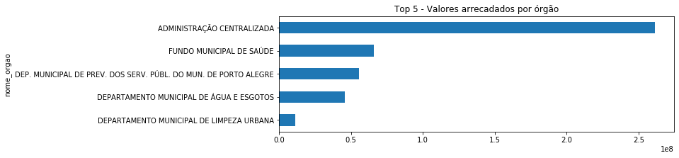

```python
#Gráfico Valor Arrecadado

ago_arrecadado = ago_arrecadado.sort_values(ascending=False)[0:5]
ago_arrecadado.sort_values().plot(figsize=(10,3), kind='barh', title="Top 5 - Valores arrecadados por órgão")
plt.show()
```

```python
#Cálculo do déficit (ou superávit) e formatação para Real

def_saude_ago = (df_ago['valor_arrecadado']['FUNDO MUNICIPAL DE SAÚDE'] - df_ago['valor_orcado']['FUNDO MUNICIPAL DE SAÚDE'])

def_prev_ago = (df_ago['valor_arrecadado']['DEP. MUNICIPAL DE PREV. DOS SERV. PÚBL. DO MUN. DE PORTO ALEGRE'] -
                df_ago['valor_orcado']['DEP. MUNICIPAL DE PREV. DOS SERV. PÚBL. DO MUN. DE PORTO ALEGRE'])

def_adm_ago = (df_ago['valor_arrecadado']['ADMINISTRAÇÃO CENTRALIZADA'] -
               df_ago['valor_orcado']['ADMINISTRAÇÃO CENTRALIZADA'])

def_agua_ago = (df_ago['valor_arrecadado']['DEPARTAMENTO MUNICIPAL DE ÁGUA E ESGOTOS'] -
                df_ago['valor_orcado']['DEPARTAMENTO MUNICIPAL DE ÁGUA E ESGOTOS'])

def_limpeza_ago = (df_ago['valor_arrecadado']['DEPARTAMENTO MUNICIPAL DE LIMPEZA URBANA'] -
                   df_ago['valor_orcado']['DEPARTAMENTO MUNICIPAL DE LIMPEZA URBANA'])

def_saude_ago_format = 'R${:,.2f}'.format(def_saude_ago)
def_prev_ago_format = 'R${:,.2f}'.format(def_prev_ago)
def_adm_ago_format = 'R${:,.2f}'.format(def_adm_ago)
def_agua_ago_format = 'R${:,.2f}'.format(def_agua_ago)
def_limpeza_ago_format = 'R${:,.2f}'.format(def_limpeza_ago)
```

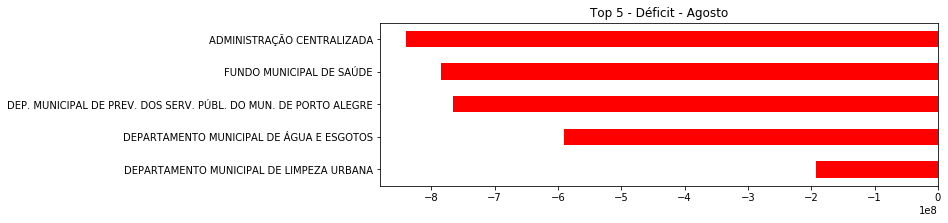

```python
#Gráfico Déficit

x_ago = ["FUNDO MUNICIPAL DE SAÚDE", "DEP. MUNICIPAL DE PREV. DOS SERV. PÚBL. DO MUN. DE PORTO ALEGRE",
         "ADMINISTRAÇÃO CENTRALIZADA", "DEPARTAMENTO MUNICIPAL DE ÁGUA E ESGOTOS", "DEPARTAMENTO MUNICIPAL DE LIMPEZA URBANA"]
y_ago = [def_saude_ago, def_prev_ago, def_adm_ago, def_agua_ago, def_limpeza_ago]

ser_ago = pd.Series(y_ago, index=x_ago)
#print(ser_ago.sort_values())

ser_ago.sort_values(ascending=False).plot(figsize=(10,3), kind='barh', title="Top 5 - Déficit - Agosto", color="red")
plt.show()
```

```python
#Déficit Formatado

print("Administração Centralizada:                                     ", def_adm_ago_format)
print("Fundo Municipal de Saúde:                                       ", def_saude_ago_format)
print("Dep. Municipal de Prev. dos Serv. Públ. do Mun. de Porto Alegre:", def_prev_ago_format)
print("Departamento Municipal de Água e Esgotos:                       ", def_agua_ago_format)
print("Departamento Municipal de Limpeza Urbana:                       ", def_limpeza_ago_format)
```

```
Administração Centralizada:                                      R$-839,025,230.97
Fundo Municipal de Saúde:                                        R$-784,572,172.02
Dep. Municipal de Prev. dos Serv. Públ. do Mun. de Porto Alegre: R$-764,959,238.38
Departamento Municipal de Água e Esgotos:                        R$-590,528,044.08
Departamento Municipal de Limpeza Urbana:                        R$-192,462,850.48
```

### Setembro

```python
#Salvando apenas os dados do mês de Setembro
df_set = df_test.loc[df_test.mes == 9]
```

```python
#Agrupamento dos valores orçados e arrecadados

df_set = df_set.groupby(['nome_orgao'])['valor_orcado', 'valor_arrecadado'].sum()
#print(df_set['valor_orcado'].sort_values(ascending=False))
set_orcado = df_set['valor_orcado'].sort_values()
```

```python
#Gráfico Valor Orçado

set_orcado = set_orcado.sort_values(ascending=False)[0:5]
set_orcado.sort_values().plot(figsize=(10,3), kind='barh', title="Top 5 - Valores orçados por órgão")
plt.show()
```

[output not shown]

```python
#print(df_set['valor_arrecadado'].sort_values(ascending=False))
set_arrecadado = df_set['valor_arrecadado'].sort_values()
```

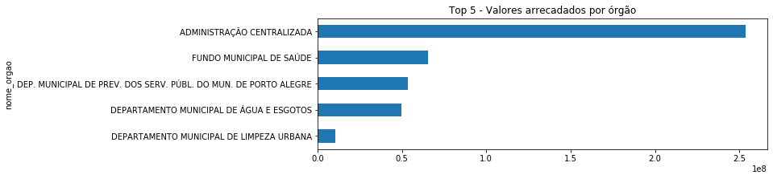

```python
#Gráfico Valor Arrecadado

set_arrecadado = set_arrecadado.sort_values(ascending=False)[0:5]
set_arrecadado.sort_values().plot(figsize=(10,3), kind='barh', title="Top 5 - Valores arrecadados por órgão")
plt.show()
```

```python
#Cálculo do déficit (ou superávit) e formatação para Real

def_saude_set = (df_set['valor_arrecadado']['FUNDO MUNICIPAL DE SAÚDE'] - df_set['valor_orcado']['FUNDO MUNICIPAL DE SAÚDE'])

def_prev_set = (df_set['valor_arrecadado']['DEP. MUNICIPAL DE PREV. DOS SERV. PÚBL. DO MUN. DE PORTO ALEGRE'] -
                df_set['valor_orcado']['DEP. MUNICIPAL DE PREV. DOS SERV. PÚBL. DO MUN. DE PORTO ALEGRE'])

def_adm_set = (df_set['valor_arrecadado']['ADMINISTRAÇÃO CENTRALIZADA'] -
               df_set['valor_orcado']['ADMINISTRAÇÃO CENTRALIZADA'])

def_agua_set = (df_set['valor_arrecadado']['DEPARTAMENTO MUNICIPAL DE ÁGUA E ESGOTOS'] -
                df_set['valor_orcado']['DEPARTAMENTO MUNICIPAL DE ÁGUA E ESGOTOS'])

def_limpeza_set = (df_set['valor_arrecadado']['DEPARTAMENTO MUNICIPAL DE LIMPEZA URBANA'] -
                   df_set['valor_orcado']['DEPARTAMENTO MUNICIPAL DE LIMPEZA URBANA'])

def_saude_set_format = 'R${:,.2f}'.format(def_saude_set)
def_prev_set_format = 'R${:,.2f}'.format(def_prev_set)
def_adm_set_format = 'R${:,.2f}'.format(def_adm_set)
def_agua_set_format = 'R${:,.2f}'.format(def_agua_set)
def_limpeza_set_format = 'R${:,.2f}'.format(def_limpeza_set)
```

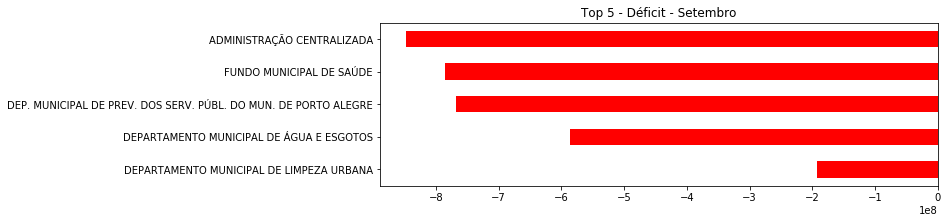

```python
#Gráfico Déficit

x_set = ["FUNDO MUNICIPAL DE SAÚDE", "DEP. MUNICIPAL DE PREV. DOS SERV. PÚBL. DO MUN. DE PORTO ALEGRE",
         "ADMINISTRAÇÃO CENTRALIZADA", "DEPARTAMENTO MUNICIPAL DE ÁGUA E ESGOTOS", "DEPARTAMENTO MUNICIPAL DE LIMPEZA URBANA"]
y_set = [def_saude_set, def_prev_set, def_adm_set, def_agua_set, def_limpeza_set]

ser_set = pd.Series(y_set, index=x_set)
#print(ser_set.sort_values())

ser_set.sort_values(ascending=False).plot(figsize=(10,3), kind='barh', title="Top 5 - Déficit - Setembro", color="red")
plt.show()
```

```python
#Déficit Formatado

print("Administração Centralizada:                                     ", def_adm_set_format)
print("Fundo Municipal de Saúde:                                       ", def_saude_set_format)
print("Dep. Municipal de Prev. dos Serv. Públ. do Mun. de Porto Alegre:", def_prev_set_format)
print("Departamento Municipal de Água e Esgotos:                       ", def_agua_set_format)
print("Departamento Municipal de Limpeza Urbana:                       ", def_limpeza_set_format)
```

```
Administração Centralizada:                                      R$-846,680,429.84
Fundo Municipal de Saúde:                                        R$-785,159,952.42
Dep. Municipal de Prev. dos Serv. Públ. do Mun. de Porto Alegre: R$-767,140,449.74
Departamento Municipal de Água e Esgotos:                        R$-586,416,332.72
Departamento Municipal de Limpeza Urbana:                        R$-192,984,854.61
```

### Outubro

```python
#Salvando apenas os dados do mês de Outubro
df_out = df_test.loc[df_test.mes == 10]
```

```python
#Agrupamento dos valores orçados e arrecadados

df_out = df_out.groupby(['nome_orgao'])['valor_orcado', 'valor_arrecadado'].sum()
#print(df_out['valor_orcado'].sort_values(ascending=False))
out_orcado = df_out['valor_orcado'].sort_values()
```

```python
#Gráfico Valor Orçado

out_orcado = out_orcado.sort_values(ascending=False)[0:5]
out_orcado.sort_values().plot(figsize=(10,3), kind='barh', title="Top 5 - Valores orçados por órgão")
plt.show()
```

[output not shown]

```python
#print(df_out['valor_arrecadado'].sort_values(ascending=False))
out_arrecadado = df_out['valor_arrecadado'].sort_values()
```

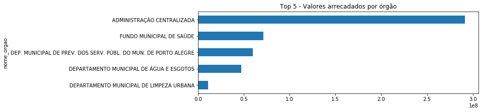

```python
#Gráfico Valor Arrecadado

out_arrecadado = out_arrecadado.sort_values(ascending=False)[0:5]
out_arrecadado.sort_values().plot(figsize=(10,3), kind='barh', title="Top 5 - Valores arrecadados por órgão")
plt.show()
```

```python
#Cálculo do déficit (ou superávit) e formatação para Real

def_saude_out = (df_out['valor_arrecadado']['FUNDO MUNICIPAL DE SAÚDE'] - df_out['valor_orcado']['FUNDO MUNICIPAL DE SAÚDE'])

def_prev_out = (df_out['valor_arrecadado']['DEP. MUNICIPAL DE PREV. DOS SERV. PÚBL. DO MUN. DE PORTO ALEGRE'] -
                df_out['valor_orcado']['DEP. MUNICIPAL DE PREV. DOS SERV. PÚBL. DO MUN. DE PORTO ALEGRE'])

def_adm_out = (df_out['valor_arrecadado']['ADMINISTRAÇÃO CENTRALIZADA'] -
               df_out['valor_orcado']['ADMINISTRAÇÃO CENTRALIZADA'])

def_agua_out = (df_out['valor_arrecadado']['DEPARTAMENTO MUNICIPAL DE ÁGUA E ESGOTOS'] -
                df_out['valor_orcado']['DEPARTAMENTO MUNICIPAL DE ÁGUA E ESGOTOS'])

def_limpeza_out = (df_out['valor_arrecadado']['DEPARTAMENTO MUNICIPAL DE LIMPEZA URBANA'] -
                   df_out['valor_orcado']['DEPARTAMENTO MUNICIPAL DE LIMPEZA URBANA'])

def_saude_out_format = 'R${:,.2f}'.format(def_saude_out)
def_prev_out_format = 'R${:,.2f}'.format(def_prev_out)
def_adm_out_format = 'R${:,.2f}'.format(def_adm_out)
def_agua_out_format = 'R${:,.2f}'.format(def_agua_out)
def_limpeza_out_format = 'R${:,.2f}'.format(def_limpeza_out)
```

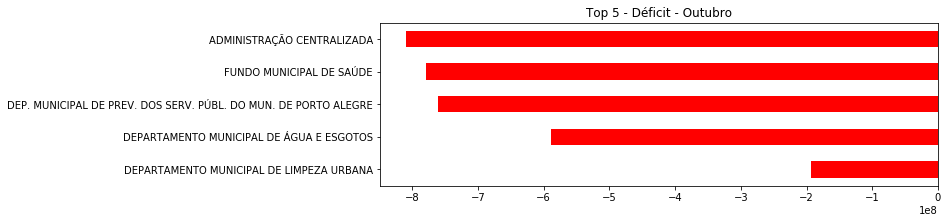

```python
#Gráfico Déficit

x_out = ["FUNDO MUNICIPAL DE SAÚDE", "DEP. MUNICIPAL DE PREV. DOS SERV. PÚBL. DO MUN. DE PORTO ALEGRE",
         "ADMINISTRAÇÃO CENTRALIZADA", "DEPARTAMENTO MUNICIPAL DE ÁGUA E ESGOTOS", "DEPARTAMENTO MUNICIPAL DE LIMPEZA URBANA"]
y_out = [def_saude_out, def_prev_out, def_adm_out, def_agua_out, def_limpeza_out]

ser_out = pd.Series(y_out, index=x_out)
#print(ser_out.sort_values())

ser_out.sort_values(ascending=False).plot(figsize=(10,3), kind='barh', title="Top 5 - Déficit - Outubro", color="red")
plt.show()
```

```python
#Déficit Formatado

print("Administração Centralizada:                                     ", def_adm_out_format)
print("Fundo Municipal de Saúde:                                       ", def_saude_out_format)
print("Dep. Municipal de Prev. dos Serv. Públ. do Mun. de Porto Alegre:", def_prev_out_format)
print("Departamento Municipal de Água e Esgotos:                       ", def_agua_out_format)
print("Departamento Municipal de Limpeza Urbana:                       ", def_limpeza_out_format)
```

```
Administração Centralizada:                                      R$-808,931,506.51
Fundo Municipal de Saúde:                                        R$-779,369,315.46
Dep. Municipal de Prev. dos Serv. Públ. do Mun. de Porto Alegre: R$-760,786,815.92
Departamento Municipal de Água e Esgotos:                        R$-589,097,872.13
Departamento Municipal de Limpeza Urbana:                        R$-192,730,611.09
```

### Novembro

```python
#Salvando apenas os dados do mês de Novembro
df_nov = df_test.loc[df_test.mes == 11]
```

```python
#Agrupamento dos valores orçados e arrecadados

df_nov = df_nov.groupby(['nome_orgao'])['valor_orcado', 'valor_arrecadado'].sum()
#print(df_nov['valor_orcado'].sort_values(ascending=False))
nov_orcado = df_nov['valor_orcado'].sort_values()
```

```python
#Gráfico Valor Orçado

nov_orcado = nov_orcado.sort_values(ascending=False)[0:5]
nov_orcado.sort_values().plot(figsize=(10,3), kind='barh', title="Top 5 - Valores orçados por órgão")
plt.show()
```

[output not shown]

```python
#print(df_nov['valor_arrecadado'].sort_values(ascending=False))
nov_arrecadado = df_nov['valor_arrecadado'].sort_values()
```

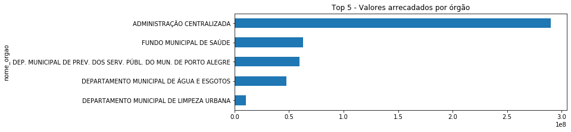

```python
#Gráfico Valor Arrecadado

nov_arrecadado = nov_arrecadado.sort_values(ascending=False)[0:5]
nov_arrecadado.sort_values().plot(figsize=(10,3), kind='barh', title="Top 5 - Valores arrecadados por órgão")
plt.show()
```

```python
#Cálculo do déficit (ou superávit) e formatação para Real

def_saude_nov = (df_nov['valor_arrecadado']['FUNDO MUNICIPAL DE SAÚDE'] - df_nov['valor_orcado']['FUNDO MUNICIPAL DE SAÚDE'])

def_prev_nov = (df_nov['valor_arrecadado']['DEP. MUNICIPAL DE PREV. DOS SERV. PÚBL. DO MUN. DE PORTO ALEGRE'] -
                df_nov['valor_orcado']['DEP. MUNICIPAL DE PREV. DOS SERV. PÚBL. DO MUN. DE PORTO ALEGRE'])

def_adm_nov = (df_nov['valor_arrecadado']['ADMINISTRAÇÃO CENTRALIZADA'] -
               df_nov['valor_orcado']['ADMINISTRAÇÃO CENTRALIZADA'])

def_agua_nov = (df_nov['valor_arrecadado']['DEPARTAMENTO MUNICIPAL DE ÁGUA E ESGOTOS'] -
                df_nov['valor_orcado']['DEPARTAMENTO MUNICIPAL DE ÁGUA E ESGOTOS'])

def_limpeza_nov = (df_nov['valor_arrecadado']['DEPARTAMENTO MUNICIPAL DE LIMPEZA URBANA'] -
                   df_nov['valor_orcado']['DEPARTAMENTO MUNICIPAL DE LIMPEZA URBANA'])

def_saude_nov_format = 'R${:,.2f}'.format(def_saude_nov)
def_prev_nov_format = 'R${:,.2f}'.format(def_prev_nov)
def_adm_nov_format = 'R${:,.2f}'.format(def_adm_nov)
def_agua_nov_format = 'R${:,.2f}'.format(def_agua_nov)
def_limpeza_nov_format = 'R${:,.2f}'.format(def_limpeza_nov)
```

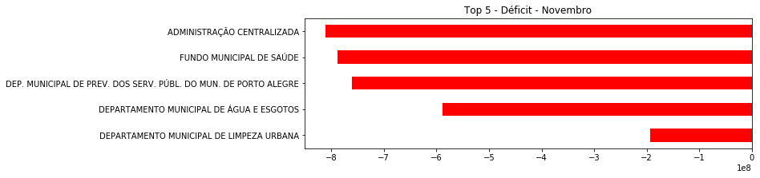

```python
#Gráfico Déficit

x_nov = ["FUNDO MUNICIPAL DE SAÚDE", "DEP. MUNICIPAL DE PREV. DOS SERV. PÚBL. DO MUN. DE PORTO ALEGRE",
         "ADMINISTRAÇÃO CENTRALIZADA", "DEPARTAMENTO MUNICIPAL DE ÁGUA E ESGOTOS", "DEPARTAMENTO MUNICIPAL DE LIMPEZA URBANA"]
y_nov = [def_saude_nov, def_prev_nov, def_adm_nov, def_agua_nov, def_limpeza_nov]

ser_nov = pd.Series(y_nov, index=x_nov)
#print(ser_nov.sort_values())

ser_nov.sort_values(ascending=False).plot(figsize=(10,3), kind='barh', title="Top 5 - Déficit - Novembro", color="red")
plt.show()
```

```python
#Déficit Formatado

print("Administração Centralizada:                                     ", def_adm_nov_format)
print("Fundo Municipal de Saúde:                                       ", def_saude_nov_format)
print("Dep. Municipal de Prev. dos Serv. Públ. do Mun. de Porto Alegre:", def_prev_nov_format)
print("Departamento Municipal de Água e Esgotos:                       ", def_agua_nov_format)
print("Departamento Municipal de Limpeza Urbana:                       ", def_limpeza_nov_format)
```

```
Administração Centralizada:                                      R$-810,211,459.01
Fundo Municipal de Saúde:                                        R$-787,816,327.43
Dep. Municipal de Prev. dos Serv. Públ. do Mun. de Porto Alegre: R$-761,052,210.33
Departamento Municipal de Água e Esgotos:                        R$-588,935,258.37
Departamento Municipal de Limpeza Urbana:                        R$-193,418,548.17
```

### Dezembro

```python
#Salvando apenas os dados do mês de Dezembro
df_dez = df_test.loc[df_test.mes == 12]
```

```python
#Agrupamento dos valores orçados e arrecadados

df_dez = df_dez.groupby(['nome_orgao'])['valor_orcado', 'valor_arrecadado'].sum()
#print(df_dez['valor_orcado'].sort_values(ascending=False))
dez_orcado = df_dez['valor_orcado'].sort_values()
```

```python
#Gráfico Valor Orçado

dez_orcado = dez_orcado.sort_values(ascending=False)[0:5]
dez_orcado.sort_values().plot(figsize=(10,3), kind='barh', title="Top 5 - Valores orçados por órgão")
plt.show()
```

[output not shown]

```python
#print(df_dez['valor_arrecadado'].sort_values(ascending=False))
dez_arrecadado = df_dez['valor_arrecadado'].sort_values()
```

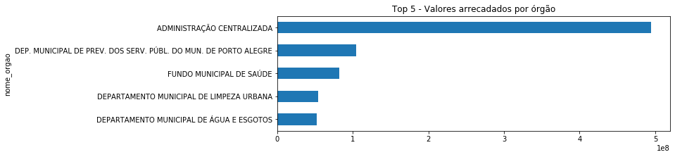

```python
#Gráfico Valor Arrecadado

dez_arrecadado = dez_arrecadado.sort_values(ascending=False)[0:5]
dez_arrecadado.sort_values().plot(figsize=(10,3), kind='barh', title="Top 5 - Valores arrecadados por órgão")
plt.show()
```

```python
#Cálculo do déficit (ou superávit) e formatação para Real

def_saude_dez = (df_dez['valor_arrecadado']['FUNDO MUNICIPAL DE SAÚDE'] - df_dez['valor_orcado']['FUNDO MUNICIPAL DE SAÚDE'])

def_prev_dez = (df_dez['valor_arrecadado']['DEP. MUNICIPAL DE PREV. DOS SERV. PÚBL. DO MUN. DE PORTO ALEGRE'] -
                df_dez['valor_orcado']['DEP. MUNICIPAL DE PREV. DOS SERV. PÚBL. DO MUN. DE PORTO ALEGRE'])

def_adm_dez = (df_dez['valor_arrecadado']['ADMINISTRAÇÃO CENTRALIZADA'] -
               df_dez['valor_orcado']['ADMINISTRAÇÃO CENTRALIZADA'])

def_agua_dez = (df_dez['valor_arrecadado']['DEPARTAMENTO MUNICIPAL DE ÁGUA E ESGOTOS'] -
                df_dez['valor_orcado']['DEPARTAMENTO MUNICIPAL DE ÁGUA E ESGOTOS'])

def_limpeza_dez = (df_dez['valor_arrecadado']['DEPARTAMENTO MUNICIPAL DE LIMPEZA URBANA'] -
                   df_dez['valor_orcado']['DEPARTAMENTO MUNICIPAL DE LIMPEZA URBANA'])

def_saude_dez_format = 'R${:,.2f}'.format(def_saude_dez)
def_prev_dez_format = 'R${:,.2f}'.format(def_prev_dez)
def_adm_dez_format = 'R${:,.2f}'.format(def_adm_dez)
def_agua_dez_format = 'R${:,.2f}'.format(def_agua_dez)
def_limpeza_dez_format = 'R${:,.2f}'.format(def_limpeza_dez)
```

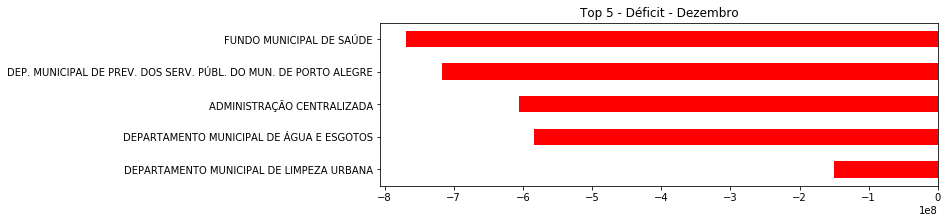

```python
#Gráfico Déficit

x_dez = ["FUNDO MUNICIPAL DE SAÚDE", "DEP. MUNICIPAL DE PREV. DOS SERV. PÚBL. DO MUN. DE PORTO ALEGRE",
         "ADMINISTRAÇÃO CENTRALIZADA", "DEPARTAMENTO MUNICIPAL DE ÁGUA E ESGOTOS", "DEPARTAMENTO MUNICIPAL DE LIMPEZA URBANA"]
y_dez = [def_saude_dez, def_prev_dez, def_adm_dez, def_agua_dez, def_limpeza_dez]

ser_dez = pd.Series(y_dez, index=x_dez)
#print(ser_dez.sort_values())

ser_dez.sort_values(ascending=False).plot(figsize=(10,3), kind='barh', title="Top 5 - Déficit - Dezembro", color="red")
plt.show()
```

```python
#Déficit Formatado

print("Fundo Municipal de Saúde:                                       ", def_saude_dez_format)
print("Dep. Municipal de Prev. dos Serv. Públ. do Mun. de Porto Alegre:", def_prev_dez_format)
print("Administração Centralizada:                                     ", def_adm_dez_format)
print("Departamento Municipal de Água e Esgotos:                       ", def_agua_dez_format)
print("Departamento Municipal de Limpeza Urbana:                       ", def_limpeza_dez_format)
```

```
Fundo Municipal de Saúde:                                        R$-768,341,748.28
Dep. Municipal de Prev. dos Serv. Públ. do Mun. de Porto Alegre: R$-716,620,236.03
Administração Centralizada:                                      R$-605,657,214.69
Departamento Municipal de Água e Esgotos:                        R$-584,591,259.39
Departamento Municipal de Limpeza Urbana:                        R$-149,906,108.83
```

## Análise Top 5 - Órgão

### Administração Centralizada

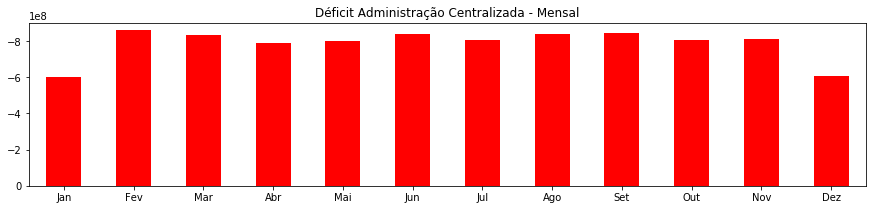

```python
#Gráfico Déficit Administração Centralizada por mês

meses = ["Jan", "Fev", "Mar", "Abr", "Mai", "Jun", "Jul", "Ago", "Set", "Out", "Nov", "Dez"]
data_adm = [def_adm_jan, def_adm_fev, def_adm_mar, def_adm_abr, def_adm_mai, def_adm_jun,
        def_adm_jul, def_adm_ago, def_adm_set, def_adm_out, def_adm_nov, def_adm_dez]

ser_adm = pd.Series(data_adm, index=meses)

ser_adm.plot(figsize=(15,3), kind='bar', title="Déficit Administração Centralizada - Mensal", color="red")
plt.xticks(rotation=0)
plt.gca().invert_yaxis()
plt.show()
```

```python
print("Janeiro:  ", def_adm_jan_format)
print("Fevereiro:", def_adm_fev_format)
print("Março:    ", def_adm_mar_format)
print("Abril:    ", def_adm_abr_format)
print("Maio:     ", def_adm_mai_format)
print("Junho:    ", def_adm_jun_format)
print("Julho:    ", def_adm_jul_format)
print("Agosto:   ", def_adm_ago_format)
print("Setembro: ", def_adm_set_format)
print("Outubro:  ", def_adm_out_format)
print("Novembro: ", def_adm_nov_format)
print("Dezembro: ", def_adm_dez_format)
```

```
Janeiro:   R$-600,457,041.77
Fevereiro: R$-859,009,087.33
Março:     R$-834,180,242.53
Abril:     R$-790,909,764.90
Maio:      R$-801,422,244.41
Junho:     R$-840,382,475.79
Julho:     R$-806,732,664.40
Agosto:    R$-839,025,230.97
Setembro:  R$-846,680,429.84
Outubro:   R$-808,931,506.51
Novembro:  R$-810,211,459.01
Dezembro:  R$-605,657,214.69
```

- Meses com maiores déficits: Fevereiro, Setembro, Junho, Agosto e Março
- Com exceção de Janeiro, Abril e Dezembro, a Administração Centralizada apresenta déficit maior que 800 milhões de reais

### Dep. Municipal de Prev. dos Serv. Públ. do Mun. de Porto Alegre

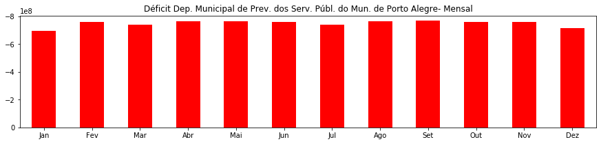

```python
#Gráfico Déficit Dep. Municipal de Prev. dos Serv. Públ. do Mun. de Porto Alegre por mês

data_prev = [def_prev_jan, def_prev_fev, def_prev_mar, def_prev_abr, def_prev_mai, def_prev_jun,
             def_prev_jul, def_prev_ago, def_prev_set, def_prev_out, def_prev_nov, def_prev_dez]

ser_prev = pd.Series(data_prev, index=meses)

ser_prev.plot(figsize=(15,3), kind='bar',
              title="Déficit Dep. Municipal de Prev. dos Serv. Públ. do Mun. de Porto Alegre- Mensal",
              color="red")
plt.xticks(rotation=0)
plt.gca().invert_yaxis()
plt.show()
```

```python
print("Janeiro:  ", def_prev_jan_format)
print("Fevereiro:", def_prev_fev_format)
print("Março:    ", def_prev_mar_format)
print("Abril:    ", def_prev_abr_format)
print("Maio:     ", def_prev_mai_format)
print("Junho:    ", def_prev_jun_format)
print("Julho:    ", def_prev_jul_format)
print("Agosto:   ", def_prev_ago_format)
print("Setembro: ", def_prev_set_format)
print("Outubro:  ", def_prev_out_format)
print("Novembro: ", def_prev_nov_format)
print("Dezembro: ", def_prev_dez_format)
```

```
Janeiro:   R$-695,951,782.50
Fevereiro: R$-759,899,650.29
Março:     R$-741,099,635.43
Abril:     R$-765,669,542.08
Maio:      R$-765,539,264.61
Junho:     R$-757,637,678.64
Julho:     R$-742,060,035.40
Agosto:    R$-764,959,238.38
Setembro:  R$-767,140,449.74
Outubro:   R$-760,786,815.92
Novembro:  R$-761,052,210.33
Dezembro:  R$-716,620,236.03
```

- Meses com maiores déficits: Setembro, Abril, Maio, Agosto e Novembro
- Apenas no mês de Janeiro houve déficit menor que 700 milhões de reais

### Fundo Municipal de Saúde

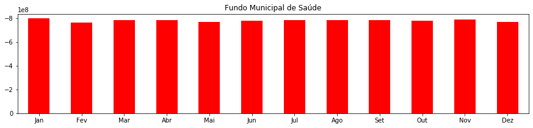

```python
data_saude = [def_saude_jan, def_saude_fev, def_saude_mar, def_saude_abr, def_saude_mai, def_saude_jun,
             def_saude_jul, def_saude_ago, def_saude_set, def_saude_out, def_saude_nov, def_saude_dez]

ser_saude = pd.Series(data_saude, index=meses)

ser_saude.plot(figsize=(15,3), kind='bar',
              title="Fundo Municipal de Saúde",
              color="red")
plt.xticks(rotation=0)
plt.gca().invert_yaxis()
plt.show()
```

```python
print("Janeiro:  ", def_saude_jan_format)
print("Fevereiro:", def_saude_fev_format)
print("Março:    ", def_saude_mar_format)
print("Abril:    ", def_saude_abr_format)
print("Maio:     ", def_saude_mai_format)
print("Junho:    ", def_saude_jun_format)
print("Julho:    ", def_saude_jul_format)
print("Agosto:   ", def_saude_ago_format)
print("Setembro: ", def_saude_set_format)
print("Outubro:  ", def_saude_out_format)
print("Novembro: ", def_saude_nov_format)
print("Dezembro: ", def_saude_dez_format)
```

```
Janeiro:   R$-796,861,889.65
Fevereiro: R$-765,086,199.29
Março:     R$-785,790,349.27
Abril:     R$-783,496,647.08
Maio:      R$-770,689,469.68
Junho:     R$-777,415,434.75
Julho:     R$-781,417,293.44
Agosto:    R$-784,572,172.02
Setembro:  R$-785,159,952.42
Outubro:   R$-779,369,315.46
Novembro:  R$-787,816,327.43
Dezembro:  R$-768,341,748.28
```

- Meses com maiores déficits: Janeiro, Novembro, Março, Setembro e Agosto
- Todos os meses apresentaram déficit maior que 760 milhões de reais

### Departamento Municipal de Água e Esgotos

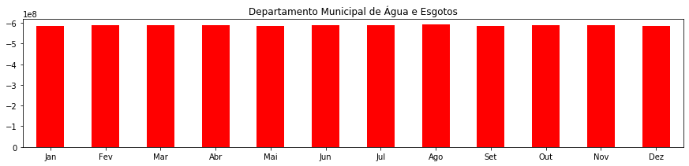

```python
data_agua = [def_agua_jan, def_agua_fev, def_agua_mar, def_agua_abr, def_agua_mai, def_agua_jun,
             def_agua_jul, def_agua_ago, def_agua_set, def_agua_out, def_agua_nov, def_agua_dez]

ser_agua = pd.Series(data_agua, index=meses)

ser_agua.plot(figsize=(15,3), kind='bar',
              title="Departamento Municipal de Água e Esgotos",
              color="red")
plt.xticks(rotation=0)
plt.gca().invert_yaxis()
plt.show()
```

```python
print("Janeiro:  ", def_agua_jan_format)
print("Fevereiro:", def_agua_fev_format)
print("Março:    ", def_agua_mar_format)
print("Abril:    ", def_agua_abr_format)
print("Maio:     ", def_agua_mai_format)
print("Junho:    ", def_agua_jun_format)
print("Julho:    ", def_agua_jul_format)
print("Agosto:   ", def_agua_ago_format)
print("Setembro: ", def_agua_set_format)
print("Outubro:  ", def_agua_out_format)
print("Novembro: ", def_agua_nov_format)
print("Dezembro: ", def_agua_dez_format)
```

```
Janeiro:   R$-583,816,683.53
Fevereiro: R$-588,547,056.59
Março:     R$-588,972,954.03
Abril:     R$-588,917,813.30
Maio:      R$-583,645,852.14
Junho:     R$-588,706,090.33
Julho:     R$-588,321,843.29
Agosto:    R$-590,528,044.08
Setembro:  R$-586,416,332.72
Outubro:   R$-589,097,872.13
Novembro:  R$-588,935,258.37
Dezembro:  R$-584,591,259.39
```

### Departamento Municipal de Limpeza Urbana

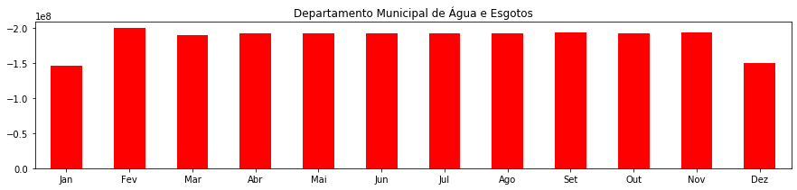

```python
data_limpeza = [def_limpeza_jan, def_limpeza_fev, def_limpeza_mar, def_limpeza_abr, def_limpeza_mai, def_limpeza_jun,
                def_limpeza_jul, def_limpeza_ago, def_limpeza_set, def_limpeza_out, def_limpeza_nov, def_limpeza_dez]

ser_limpeza = pd.Series(data_limpeza, index=meses)

ser_limpeza.plot(figsize=(15,3), kind='bar',
              title="Departamento Municipal de Água e Esgotos",
              color="red")
plt.xticks(rotation=0)
plt.gca().invert_yaxis()
plt.show()
```

```python
print("Janeiro:  ", def_limpeza_jan_format)
print("Fevereiro:", def_limpeza_fev_format)
print("Março:    ", def_limpeza_mar_format)
print("Abril:    ", def_limpeza_abr_format)
print("Maio:     ", def_limpeza_mai_format)
print("Junho:    ", def_limpeza_jun_format)
print("Julho:    ", def_limpeza_jul_format)
print("Agosto:   ", def_limpeza_ago_format)
print("Setembro: ", def_limpeza_set_format)
print("Outubro:  ", def_limpeza_out_format)
print("Novembro: ", def_limpeza_nov_format)
print("Dezembro: ", def_limpeza_dez_format)
```

```
Janeiro:   R$-146,157,137.99
Fevereiro: R$-199,415,807.06
Março:     R$-189,542,286.23
Abril:     R$-191,806,945.44
Maio:      R$-192,065,022.15
Junho:     R$-191,852,936.44
Julho:     R$-192,770,480.03
Agosto:    R$-192,462,850.48
Setembro:  R$-192,984,854.61
Outubro:   R$-192,730,611.09
Novembro:  R$-193,418,548.17
Dezembro:  R$-149,906,108.83
```

- Meses com maiores déficits: Fevereiro, Novembro, Setembro, Julho e Outubro
- Janeiro e Dezembro possuem os menores déficits
- Demais meses apresentam déficits semelhantes

### Análise dos totais

```python
ser_def_jan = def_limpeza_jan + def_agua_jan + def_prev_jan + def_saude_jan + def_adm_jan
ser_def_fev = def_limpeza_fev + def_agua_fev + def_prev_fev + def_saude_fev + def_adm_fev
ser_def_mar = def_limpeza_mar + def_agua_mar + def_prev_mar + def_saude_mar + def_adm_mar
ser_def_abr = def_limpeza_abr + def_agua_abr + def_prev_abr + def_saude_abr + def_adm_abr
ser_def_mai = def_limpeza_mai + def_agua_mai + def_prev_mai + def_saude_mai + def_adm_mai
ser_def_jun = def_limpeza_jun + def_agua_jun + def_prev_jun + def_saude_jun + def_adm_jun
ser_def_jul = def_limpeza_jul + def_agua_jul + def_prev_jul + def_saude_jul + def_adm_jul
ser_def_ago = def_limpeza_ago + def_agua_ago + def_prev_ago + def_saude_ago + def_adm_ago
ser_def_set = def_limpeza_set + def_agua_set + def_prev_set + def_saude_set + def_adm_set
ser_def_out = def_limpeza_out + def_agua_out + def_prev_out + def_saude_out + def_adm_out
ser_def_nov = def_limpeza_nov + def_agua_nov + def_prev_nov + def_saude_nov + def_adm_nov
ser_def_dez = def_limpeza_dez + def_agua_dez + def_prev_dez + def_saude_dez + def_adm_dez
```

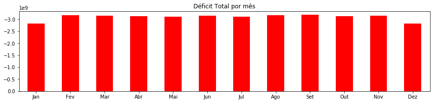

```python
data_def = [ser_def_jan, ser_def_fev, ser_def_mar, ser_def_abr, ser_def_mai, ser_def_jun,
            ser_def_jul, ser_def_ago, ser_def_set, ser_def_out, ser_def_nov, ser_def_dez]

ser_def = pd.Series(data_def, index=meses)

ser_def.plot(figsize=(15,3), kind='bar',
              title="Déficit Total por mês",
              color="red")
plt.xticks(rotation=0)
plt.gca().invert_yaxis()
plt.show()
```

```python
ser_def_jan_format = 'R${:,.2f}'.format(ser_def_jan)
ser_def_fev_format = 'R${:,.2f}'.format(ser_def_fev)
ser_def_mar_format = 'R${:,.2f}'.format(ser_def_mar)
ser_def_abr_format = 'R${:,.2f}'.format(ser_def_abr)
ser_def_mai_format = 'R${:,.2f}'.format(ser_def_mai)
ser_def_jun_format = 'R${:,.2f}'.format(ser_def_jun)
ser_def_jul_format = 'R${:,.2f}'.format(ser_def_jul)
ser_def_ago_format = 'R${:,.2f}'.format(ser_def_ago)
ser_def_set_format = 'R${:,.2f}'.format(ser_def_set)
ser_def_out_format = 'R${:,.2f}'.format(ser_def_out)
ser_def_nov_format = 'R${:,.2f}'.format(ser_def_nov)
ser_def_dez_format = 'R${:,.2f}'.format(ser_def_dez)
```

```python
print("Total por mês")
print()
print("Janeiro:   ",ser_def_jan_format)
print("Fevereiro: ",ser_def_fev_format)
print("Março:     ",ser_def_mar_format)
print("Abril:     ",ser_def_abr_format)
print("Maio:      ",ser_def_mai_format)
print("Junho:     ",ser_def_jun_format)
print("Julho:     ",ser_def_jul_format)
print("Agosto:    ",ser_def_ago_format)
print("Setembro:  ",ser_def_set_format)
print("Outubro:   ",ser_def_out_format)
print("Novembro:  ",ser_def_nov_format)
print("Dezembro:  ",ser_def_dez_format)
```

```
Total por mês

Janeiro:    R$-2,823,244,535.44
Fevereiro:  R$-3,171,957,800.56
Março:      R$-3,139,585,467.49
Abril:      R$-3,120,800,712.80
Maio:       R$-3,113,361,852.99
Junho:      R$-3,155,994,615.95
Julho:      R$-3,111,302,316.56
Agosto:     R$-3,171,547,535.93
Setembro:   R$-3,178,382,019.33
Outubro:    R$-3,130,916,121.11
Novembro:   R$-3,141,433,803.31
Dezembro:   R$-2,825,116,567.22
```

```python
total = (ser_def_jan + ser_def_fev + ser_def_mar + ser_def_abr + ser_def_mai + ser_def_jun +
         ser_def_jul + ser_def_ago + ser_def_set + ser_def_out + ser_def_nov + ser_def_dez)
```

```python
total_format = 'R${:,.2f}'.format(total)
print("Total geral: ", total_format)
```

```
Total geral:  R$-37,083,643,348.69
```

```python
media = total / 12
media_format = 'R${:,.2f}'.format(media)
print("Média: ", media_format)
```

```
Média:  R$-3,090,303,612.39
```